# Homework

Li Wenmei

2021-12-20

#### First homework

### Question

Exercises 3.3,3.4,3.5(page 94 ,Statistical Computating with R )

### Answer

3.3 The Pareto(2,2) distribution has cdf $F(x)=1-(\frac{2}{x})^2,x>2$,we derive the probability inverse transformation,and use the inverse transform method to simulate a random sample from the Pareto(2,2) distribution. and graph the density histogram of the sample with the Pareto(2,2) density superimposed for comparison.Therefore, it is reasonable for us to obtain the original values of random variables by random sampling of uniform distribution and inverse transformation method, and it is relatively simple to sample uniform distribution, which greatly reduces the difficulty of sampling random variables with complex distribution.

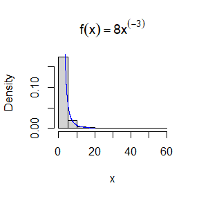

```r
set.seed(12345)
library(stats)
r<-runif(1000)
x<-2/((r)^(1/2))#  Derive the inverse function
hist(x,prob=TRUE,main=expression(f(x)==8*x^(-3)))
y<-seq(2,20,.01)
lines(y,8*y^(-3),col="blue")
```

From the histogram and density plot in above figure, we can see that the empirical and theoretical distributions approximately agree.

3.4 Develop an algorithm to generate random samples from a Rayleigh($\sigma$) distribution.Generate Rayleigh($\sigma$) samples for several choices of $\sigma$ > 0 ,now Might as well set $\sigma$=1,and checkthat the mode of the generated samples is close to the theoretical mode $\sigma$(check the histogram). The Rayleigh(1) distribution has cdf $F(x)=1-e^{-{(\frac{x}{2})^2}}$, according to the inverse transformation method,we have $x=(-2lnU)^\frac{1}{2}$

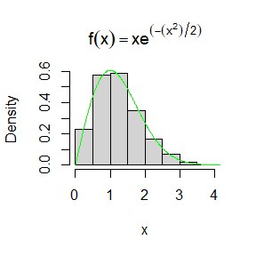

```r
u<-runif(1000)
x<-(-2*log(u))^(1/2)
hist(x,prob=TRUE,main=expression(f(x)==x*e^(-(x^2)/2)))
y<-seq(0,100,.01)
y1<-y*exp(-(y^2)/2)
lines(y,y1,col="green")
```

From the histogram and density plot in above figure, we can see that the empirical and theoretical distributions approximately agree.Therefore, it is reasonable for us to obtain the original values of random variables by random sampling of uniform distribution and inverse transformation method, and it is relatively simple to sample uniform distribution, which greatly reduces the difficulty of sampling random variables with complex distribution

3.5 For a discrete random variable X,Use the inverse transform method to generate a random sample of size 1000 from the distribution of X. Construct a relative frequency table and compare the empirical with the theoretical probabilities. Repeat using the R sample function.

```r
p<-c(0.1,0.2,0.2,0.2,0.3)
library(knitr)
res<-data.frame(x=c(0,1,2,3,4),p=c(0.1,0.2,0.2,0.2,0.3))
kable(res,digits = getOption("digits"),align = "lccrr")
```

| x | p |
| --- | --- |
| 0 | 0.1 |
| 1 | 0.2 |
| 2 | 0.2 |
| 3 | 0.2 |
| 4 | 0.3 |

```r
x<-sample(c(0,1,2,3,4),size=1000,replace=TRUE,prob=c(0.1,0.2,0.2,0.2,0.3))
p0<-sum(x==0)/1000
p1<-sum(x==1)/1000
p2<-sum(x==2)/1000
p3<-sum(x==3)/1000
p4<-sum(x==4)/1000
data.frame(p0,p1,p2,p3,p4)
```

```
##      p0    p1    p2    p3    p4
## 1 0.092 0.208 0.184 0.197 0.319
```

```r
res1<-data.frame(x=c(0,1,2,3,4),t_p=c(0.1,0.2,0.2,0.2,0.3),e_p=c(p0,p1,p2,p3,p4))
kable(res1,digits = getOption("digits"),align = "lccrr",label = "Empirical with the theoretical probabilities ")
```

| x | t_p | e_p |
| --- | --- | --- |
| 0 | 0.1 | 0.092 |
| 1 | 0.2 | 0.208 |
| 2 | 0.2 | 0.184 |
| 3 | 0.2 | 0.197 |
| 4 | 0.3 | 0.319 |

#### Second homework

### Question

Exercises3.4,3.11,and3.20(pages94-96,StatisticalComputaing with R)

3.4 The Rayleigh density [156, Ch. 18] is
$$f(x)={\frac{x}{\sigma^2}}e^{-\frac{x^2}{2\sigma^2}},x\geq0,\sigma\geq0.$$
Develop an algorithm to generate random samples from a Rayleigh($\sigma$) distribution. Generate Rayleigh($\sigma$) samples for several choices of $\sigma>0$ and checkthat the mode of the generated samples is close to the theoretical mode $\sigma$(check the histogram)

3.11 Generate a random sample of size 1000 from a normal location mixture. The components of the mixture have N(0,1) and N(3,1) distributions with mixing probabilities $p_1$ and $p_2=1-p_1$. Graph the histogram of the sample with density superimposed, for $p_1=0.75$. Repeat with different values for $p_1$ and observe whether the empirical distribution of the mixture appears to be bimodal. Make a conjecture about the values of $p_1$ that produce bimodal mixtures.

3.20 A compound Poisson process is a stochastic process$\{X(t),t\geq0\}$ that can be represented as the random sum $X(t)=\sum_{i=0}^{N(t)}Y_i,t\geq0,where \{N(t),t\geq0\}$ is a Poisson process and $Y_1,Y_2,...$ are idd and indenpent of $\{N(t),t\geq0\}$. Write a program to simulate a compound Poisson($\lambda$)-Gamma process (Y has a Gamma distribution). Estimate the mean and the variance of X(10) for several choices of the parameters and compare with the theoretical values. Hint: Show that $E[X(t)]=\lambda{t}E[Y_1]$ and $Var(X(t))=\lambda{E[{Y_1}^2]}$

### Answer

3.4 Because we already know the Rayleigh density,We can easily figure out its distribution function $F(x)=1-e^{-\frac{x^2}{2{\sigma}^2}}$,now we will generate Rayleigh($\sigma$) samples for $\sigma=1,5,10$ and Graph the histogram of the sample with density superimposed.

Algorithm is as follows: (1) for $\sigma=1,5,10$, the corresponding distribution function is $F_1(x)=1-e^{-\frac{x^2}{2}},F_2(x)=1-e^{-\frac{x^2}{50}},F_3(x)=1-e^{-\frac{x^2}{200}}$

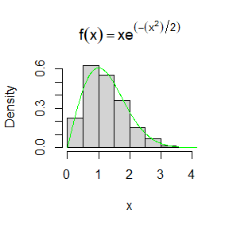

```r
library(ggplot2)
set.seed(12345)
u<-runif(1000) #Generate 1000 independent and uniformly distributed random variables
# for sigma=1
x<-(-2*log(u))^(1/2)
#graph the histogram
hist(x,prob=TRUE,main=expression(f(x)==x*e^(-(x^2)/2) ))
#Graph the density curve
y<-seq(0,100,.01)
y1<-y*exp(-(y^2)/2)
lines(y,y1,col="green")
```

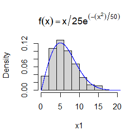

```r
# for sigma=5
x1<-(-50*log(u))^(1/2)
#graph the histogram
hist(x1,prob=TRUE,main=expression(f(x)==x/25*e^(-(x^2)/50)))
#Graph the density curve
y<-seq(0,100,.01)
y1<-y/25*exp(-(y^2)/50)
lines(y,y1,col="blue")
```

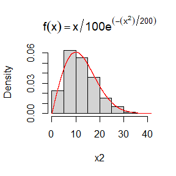

```r
# for sigma=10
x2<-(-200*log(u))^(1/2)
#graph the histogram
hist(x2,prob=TRUE,main=expression(f(x)==x/100*e^(-(x^2)/200)))
#Graph the density curve
y<-seq(0,100,.01)
y1<-y/100*exp(-(y^2)/200)
lines(y,y1,col="red")
```

As can be seen from the above three figures, for sigma=1,5,10, the histogram of the sample obtained by the inverse transformation method is consistent with its density curve, so the random samples generated from the model follow the theoretical distribution.

3.11 We generate random numbers directly from two normal distributions and obtain the mixed distribution as follows.

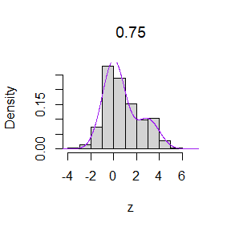

```r
set.seed(12345)
n <- 1000
z<-c(0,length(n))
## for p1=0.75
for(i in 1:n)
{
 u<-runif(1)
  if(u<0.75)
   z[i]=rnorm(1)
  else
    z[i]=rnorm(1,3,1)
}
hist(z,prob=TRUE,main=expression(mixture_distribution_p1=0.75))
y<-seq(-100,100,.01)
y1<-(0.75/((2*pi)^(1/2)))*exp(-(y^2)/2)+(0.25/((2*pi)^(1/2)))*exp(-((y-3)^2)/2)
lines(y,y1,col="purple")
```

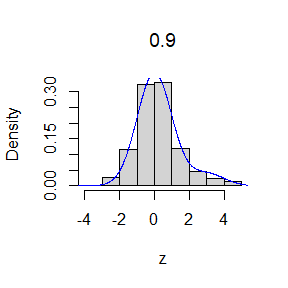

```r
## we will consider the other value of p1
# p1=0.9,then we have
for(i in 1:n)
{
 u<-runif(1)
  if(u<0.9)
   z[i]=rnorm(1)
  else
    z[i]=rnorm(1,3,1)
}
hist(z,prob=TRUE,main=expression(mixture_distribution_p1=0.9))
y<-seq(-100,100,.01)
y1<-(0.9/((2*pi)^(1/2)))*exp(-(y^2)/2)+(0.1/((2*pi)^(1/2)))*exp(-((y-3)^2)/2)
lines(y,y1,col="blue")
```

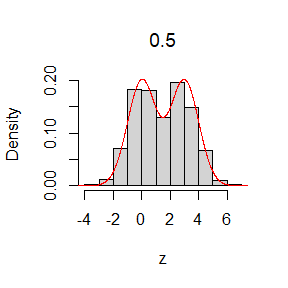

```r
# p1=0.5,then we have
for(i in 1:n)
{
 u<-runif(1)
  if(u<0.5)
   z[i]=rnorm(1)
  else
    z[i]=rnorm(1,3,1)
}
hist(z,prob=TRUE,main=expression(mixture_distribution_p1=0.5))
y<-seq(-100,100,.01)
y1<-(0.5/((2*pi)^(1/2)))*exp(-(y^2)/2)+(0.5/((2*pi)^(1/2)))*exp(-((y-3)^2)/2)
lines(y,y1,col="red")
```

As can be seen from the above three histograms, the smaller the difference between $p_1$ and $p_2$ is, the more obvious the bimodal of the mixed distribution is. When the difference between $P_1$ and $P_2$ is larger, the histogram shows that the bimodal of the mixed distribution is not obvious. For example, in the second picture, $p_1=0.9$, $p_2=0.1$, and the histogram almost presents a single peak.

3.20 So let’s say $\lambda=2$

```r
set.seed(12345)
lambda <-2
t0<-10
supper<-100
N_t<-numeric(10000)
for (i in 1:10000) {
N<-rpois(1,lambda*supper)
Un<-runif(N,0,supper) #unordered arrival times
Sn<-sort(Un) #arrival times
n <- min(which(Sn>t0)) #arrivals+1 in [0, t0]
N_t[i] <- n - 1 #arrivals in [0, t0]
}
N_10=ceiling(mean(N_t))
N_10
```

```
## [1] 21
```

```r
x<-c(0,length(1000))
for(i in 1:1000)
{
  y<- rgamma(N_10,4,5)
  x[i]<-sum(y)
}
Y<- rgamma(N_10,4,5)
res<-data.frame(mean(x),lambda*t0*0.8,var(x),lambda*t0*4/25)
kable(res,digits = getOption("digits"),align = "lccrr")
```

| mean.x. | lambda…t0…0.8 | var.x. | lambda…t0…4.25 |
| --- | --- | --- | --- |
| 16.84854 | 16 | 3.272266 | 3.2 |

As can be seen from the final output of the model,both the equation $E[X(t)]=\lambda{t}E[Y_1]$ and the equaton $Var(X(t)) =\lambda{E[{Y_1}^2]}$ is hold on, so the sampling method we adopted is feasible.

#### Third homework

### Question 5.4

Write a function to compute a Monte Carlo estimate of the Beta(3,3) cdf, and use the function to estimate F(x) for x = 0.1, 0.2,…, 0.9. Compare the estimates with the values returned by the pbeta function in R.

### Answer

```r
beta_cdf<-function(x){
  n<-10000
  t<-runif(n,0,x)
  theta.hat<-mean(t^2*(1-t)^2/beta(3,3)*x)
  return(theta.hat)
}
Monte_Carlo_estimate<-numeric(9)
Beta_cdf<-numeric(9)
for (i in 1:9){
  Monte_Carlo_estimate[i]=beta_cdf(i*0.1)
  Beta_cdf[i]=pbeta(i*0.1,3,3)
}
res<-data.frame(Monte_Carlo_estimate,Beta_cdf)
kable(res,digits = getOption("digits"),align = "lccrr")
```

| Monte_Carlo_estimate | Beta_cdf |
| --- | --- |
| 0.0085301 | 0.00856 |
| 0.0577243 | 0.05792 |
| 0.1620946 | 0.16308 |
| 0.3171129 | 0.31744 |
| 0.5005384 | 0.50000 |
| 0.6800389 | 0.68256 |
| 0.8405293 | 0.83692 |
| 0.9536735 | 0.94208 |
| 0.9889481 | 0.99144 |

From the table we can clear see, by comparing the estimates with the values return by the pbeta function in R,the Monte Carlo estimate of the Beta(3,3) cdf is approximately to the real cdf of Beta(3,3)

### Question 5.9

The Rayleigh density [156, (18.76)] is
$$f(x)={\frac{x}{{\sigma}^2}}e^{-{\frac{x^2}{2{\sigma}^2}}},x\geq0,\sigma\geq0.$$
Implement a function to generate samples from a Rayleigh($\sigma$) distribution,using antithetic variables. What is the percent reduction in variance of${\frac{x+x'}{2}}$compared with${\frac{x_1+x_2}{2}}$for independent $x_1,x_2$?

### Answer

In this example the target parameter is $\theta=xE_U[{\frac{t}{{\sigma}^2}e^{-\frac{U^2}{2\sigma^2}}}]$,U~U(0,x).now,we will discuss sevel situation,$\sigma=1,2,3,4,5$

```r
###using antithetic variables
library(knitr)
Mc<-function(x,m,R=10000,antithetic=TRUE)##,and the m is parameter.
  {
  u<-runif(R/2)
  if(!antithetic)v<-runif(R/2)
  else v<-1-u
  t<-c(u,v)
  theta_hat<-mean(x^2*t/m^2*exp(-x^2*t^2/2/m^2))
}
k<-1000
Mc1<-numeric(k)
Mc2<-numeric(k)
Mc3<-numeric(k)
Mc4<-numeric(k)
Mc5<-numeric(k)
x<-c(1,2,3,4,5)
m<-c(1,2,3,4,5)
sigma<-c(1,2,3,4,5)
for(j in 1:k)
 {
      Mc1[j]<-Mc(x[1],m[1])
      Mc2[j]<-Mc(x[2],m[2])
      Mc3[j]<-Mc(x[3],m[3])
      Mc4[j]<-Mc(x[4],m[4])
      Mc5[j]<-Mc(x[5],m[5])
}

antithetic_variables<-c(var(Mc1),var(Mc2),var(Mc3),var(Mc4),var(Mc5))
####for the independent variables
MC_independent<-function(x,m,R=10000)##,and the m is parameter.
  {
  u<-runif(R/2)
  v<-runif(R/2)
  theta_hat<-mean(x^2*u/m^2*exp(-x^2*u^2/2/m^2)+x^2*v/m^2*exp(-x^2*v^2/2/m^2))
}
Mc6<-numeric(k)
Mc7<-numeric(k)
Mc8<-numeric(k)
Mc9<-numeric(k)
Mc10<-numeric(k)
for(j in 1:k)
 {
      Mc6[j]<-MC_independent(x[1],m[1])
      Mc7[j]<-MC_independent(x[2],m[2])
      Mc8[j]<-MC_independent(x[3],m[3])
      Mc9[j]<-MC_independent(x[4],m[4])
      Mc10[j]<-MC_independent(x[5],m[5])
}
independent_variables<-c(var(Mc6),var(Mc7),var(Mc8),var(Mc9),var(Mc10))
variance_reduction_percent<-c((var(Mc6)-var(Mc1))/var(Mc6),(var(Mc7)-var(Mc2))/var(Mc7),(var(Mc8)-var(Mc3))/var(Mc8),(var(Mc9)-var(Mc4))/var(Mc9),(var(Mc10)-var(Mc5))/var(Mc10))
res<-data.frame(x,sigma,antithetic_variables,independent_variables,variance_reduction_percent)
kable(res,digits = getOption("digits"),align = "lccrr")
```

| x | sigma | antithetic_variables | independent_variables | variance_reduction_percent |
| --- | --- | --- | --- | --- |
| 1 | 1 | 4e-07 | 1.42e-05 | 0.9753042 |
| 2 | 2 | 3e-07 | 1.40e-05 | 0.9764651 |
| 3 | 3 | 4e-07 | 1.34e-05 | 0.9735751 |
| 4 | 4 | 3e-07 | 1.48e-05 | 0.9776701 |
| 5 | 5 | 3e-07 | 1.43e-05 | 0.9770659 |

For this exam,we consider x=i,$\sigma=i,i=1,...,5$ five kinds of situations, we always have the percent reduction in variance of${\frac{x+x'}{2}}$ compared with ${\frac{x_1+x_2}{2}}$for independent $x_1,x_2$ is nearly 97%

### Question 5.13

Find two importance functions $f_1$ and $f_2$ that are supported on $(1,\infty)$ and are ‘close’ to
$$g(x)={\frac{x^2}{\sqrt{2\pi}}}e^{-\frac{x^2}{2}},x\geq0.$$
Which of your two importance functions should produce the smaller variance in estimating
$$\int_1^\infty{\frac{x^2}{\sqrt{2\pi}}}e^{-\frac{x^2}{2}}dx$$
by importance sampling? Explain.

### Answer

For this case, we will consider $f_1(x)={\frac{1}{\sqrt{2\pi}}}e^{-\frac{x^2}{2}},f_2(x)=xe^{-\frac{x^2}{2}}$, both $f_1(x)$ and $f_2(x)$ are density function, and $f_1(x)>0,f_2(x)>0$ for all x belong to $(1,\infty)$.

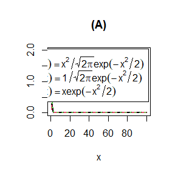

```r
 x <- seq(1, 100, .01)
g<-x^2/sqrt(2*pi)*exp(-x^2/2)
f1<-1/sqrt(2*pi)*exp(-x^2/2)
f2<-x*exp(-x^2/2)
gs <- c(
            expression(g(x)==x^2/sqrt(2*pi)*exp(-x^2/2)),
            expression(f[1](x)==1/sqrt(2*pi)*exp(-x^2/2)),
            expression(f[2](x)==x*exp(-x^2/2))
            )
 plot(x,g,type = "l", ylab = "",
         ylim = c(0,2), lwd=2,col=1,main='(A)')
    lines(x, f1, lty = 2, lwd = 2,col=2)
    lines(x, f2, lty = 3, lwd = 2,col=3)
legend("topright", legend = gs,
           lty = 1:3,lwd=2, inset=0.02,col=1:3)
```

As can be seen from the figure above, the image of $f_2(x)$ and g(x) is closer, so selecting $f_2(x)$ as an important function can produce smaller variance than selecting $f_1(x)$ as an important function.

### Question 5.14

Obtain a Monte Carlo estimate of
$$\int_1^\infty{\frac{x^2}{\sqrt{2\pi}}}e^{-\frac{x^2}{2}}dx$$
by importance sampling.

### Answer

According to problem 5.13, we consider integrals of functions $f_1(x)$ and $f_2(x)$ as important functions respectively.

```r
### now we will compute the intergation
set.seed(12345)
m<-10000
  est<-sd<-numeric(2)
  g<-function(x) {
 x^2/sqrt(2*pi)*exp(-x^2/2)*(x>1)
  }
### for the f1(x)
x<-rnorm(m)
  fg<-g(x)/(1/sqrt(2*pi)*exp(-x^2/2))
  est[1]<-mean(fg)
  sd[1]<-sd(fg)
### for the f2(x)
u<-runif(m)
x<-sqrt(-2*log(u))
fg<-g(x)/(x*exp(-x^2/2))
  est[2]<-mean(fg)
  sd[2]<-sd(fg)
  res<-rbind(est=round(est,3), sd=round(sd,3))
  colnames(res)<-paste0('f',1:2)
 knitr::kable(res,digits = getOption("digits"),align = "lccrr")
```

|  | f1 | f2 |
| --- | --- | --- |
| est | 0.400 | 0.401 |
| sd | 1.108 | 0.358 |

The results in the table above show that our judgment in Example 5.13 is correct, and the Monte Carlo estimate of $\int_1^\infty{\frac{x^2}{\sqrt{2\pi}}}e^{-\frac{x^2}{2}}dx$ by importance sampling is about 0.4.

#### Forth homework

### Question 6.5

Suppose a 95% symmetric t-interval is applied to estimate a mean, but the sample data are non-normal. Then the probability that the confidence interval covers the mean is not necessarily equal to 0.95. Use a Monte Carlo experiment to estimate the coverage probability of the t-interval for random samples of $\chi^2(2)$ data with sample size n = 20. Compare your t-interval results with the simulation results in Example 6.4. (The t-interval should be more robust to departures from normality than the interval for variance.)

### Answer

```r
set.seed(12345)
####Now we will compute the probability that the confidence interval covers in example 6.4
## we use sample which are normal
n<-20
alpha <-.05
UCL<-replicate(1000, expr = {
x<-rnorm(n, mean = 0, sd = 2)
(n-1)*var(x)/qchisq(alpha,df = n-1)
} )
#or compute the mean to get the confidence level
print("the coverage probability of the t-interval for variance which sample are normal")
```

```
## [1] "the coverage probability of the t-interval for variance which sample are normal"
```

```r
mean(UCL>4)
```

```
## [1] 0.94
```

```r
###we use sample which are non-normal
n<-20
alpha <-.05
UCL <- replicate(1000, expr = {
x<-rchisq(n,2)
(n-1)*var(x)/qchisq(alpha,df = n-1)
} )
#or compute the mean to get the confidence level
print("the coverage probability of the t-interval for variance which sample are non-normal")
```

```
## [1] "the coverage probability of the t-interval for variance which sample are non-normal"
```

```r
mean(UCL>4)
```

```
## [1] 0.776
```

```r
####Now we will compute the probability that the confidence interval covers in this case
n<-20
CL<-replicate(1000, expr = {
   x<-rchisq(n,2)
   sqrt(n)*(mean(x)-2)/2
} )
In<-mean((CL>(-qt(0.025,n-1,lower.tail=F)))&(CL<qt(0.025,n-1,lower.tail = F)))
print("the coverage probability of the t-interval for mean which sample are non-normal:")
```

```
## [1] "the coverage probability of the t-interval for mean which sample are non-normal:"
```

```r
print(In)
```

```
## [1] 0.959
```

### Question 6.A

Use Monte Carlo simulation to investigate whether the empirical Type I error rate of the t-test is approximately equal to the nominal significance level$\alpha$, when the sampled population is non-normal. The t-test is robust to mild departures from normality. Discuss the simulation results for the cases where the sampled population is

1. $\chi^2(1)$ (ii)$Uniform(0,2)$ (iii)$Exponential(1)$.

In each case, test $H_0:\mu=\mu_0$ vs $H_0:\mu\neq\mu_0$, where $\mu_0$ is the mean of $\chi^2(1)$, Uniform(0,2), and Exponential(1), respectively.

### Answer

The mean of each of these distributions is 1.

```r
set.seed(1234)
library(knitr)
##(i)chi-square
n <-100
alpha <-.05
mu0<-1
sigma <-2
x_hat<-x_se <- numeric()
p.hat<-se.hat<-p_value<-Mc_Simulation<-numeric(3)
m<-10000 #number of replicates
p<-numeric(m) #storage for p-values
for(j in 1:m){
x<-rchisq(n,1)
ttest <- t.test(x, mu=mu0)
p[j]<-ttest$p.value
x_hat[j] <-mean(x)
x_se[j] <- sd(x)
}
p2<-2*(1-pt(abs(sqrt(n)*(x_hat-mu0)/x_se),df=n-1))
Mc_Simulation[1]<-mean(p2<0.05)#we obtain the tle by Monte Carlo simulation
p_value[1]<-mean(p)##p-value, help judge whether we should reject null hypothesis
p.hat[1]<-mean(p<alpha)#we obtain the tle by using t.test
se.hat[1]<-sqrt(p.hat[1]*(1-p.hat[1])/m)#standard error

##(ii)Uniform(0,2)
n<-100
alpha <-.05
mu0<-1
sigma<-2
m<-10000 #number of replicates
p<-numeric(m) #storage for p-values
for(j in 1:m){
x<-runif(n,0,2)
ttest<-t.test(x,alternative = "greater", mu=mu0)
p[j]<-ttest$p.value
x_hat[j]<-mean(x)
x_se[j]<- sd(x)

}
p_value[2]<-mean(p)##p-value, help judge whether we should reject null hypothesis
p.hat[2]<-mean(p<alpha)#we obtain the tle by using t.test
se.hat[2]<-sqrt(p.hat[2]*(1-p.hat[2])/m)#standard error
p2<-2*(1-pt(abs(sqrt(n)*(x_hat-mu0)/x_se),df=n-1))
Mc_Simulation[2]<-mean(p2<0.05)#we obtain the tle by Monte Carlo simulation

##(iii)exp(1)
n <-100
alpha <-.05
mu0<-1
sigma <-2
m<-10000 #number of replicates
p<-numeric(m) #storage for p-values
for(j in 1:m) {
x<-rexp(n,1)
ttest <- t.test(x, mu=mu0)
p[j]<-ttest$p.value
x_hat[j] <-mean(x)
x_se[j] <- sd(x)
}
p_value[3]<-mean(p)##p-value, help judge whether we should reject null hypothesis
p.hat[3]<-mean(p<alpha)#we obtain the tle by using t.test
se.hat[3]<-sqrt(p.hat[3]*(1-p.hat[3])/m)#standard error
p2<-2*(1-pt(abs(sqrt(n)*(x_hat-mu0)/x_se),df=n-1))
Mc_Simulation[3]<-mean(p2<0.05)#we obtain the tle by Monte Carlo simulation

res<-rbind(Mc_Simulation=round(Mc_Simulation,4),p.hat=round(p.hat,4),se.hat=round(se.hat,4),p_value=round(p_value,4))
colnames(res)<-paste0(c("chi-square","Uniform","Exponential"))
kable(res,digits = getOption("digits"),align = "lccrr")
```

|  | chi-square | Uniform | Exponential |
| --- | --- | --- | --- |
| Mc_Simulation | 0.0633 | 0.0485 | 0.0578 |
| p.hat | 0.0633 | 0.0486 | 0.0578 |
| se.hat | 0.0024 | 0.0022 | 0.0023 |
| p_value | 0.4929 | 0.5028 | 0.4963 |

```r
#"chi-square","Uniform","Exponential"
```

### Question

If we obtain the powers for two methods under a particular simulation setting with 10,000 experiments: say, 0.651 for one method and 0.676 for another method. We want to know if the powers are different at 0.05 level. (1)What is the corresponding hypothesis test problem? (2)What test should we use? Z-test, two-sample t-test, paired-t test or McNemar test? Why? (3)Please provide the least necessary information for hypothesis testing

### Answer

1. Now we denote the powers for two methods as $p_1$ and $p_2$, then the corresponding hypothesis test problem is:$H_0:p_1=p_2$ vs $H_1:p_1{\neq}p_2$
2. We’re testing the same sample here, the power of two methods use the same sample is not independent, so we can not use two-sample t-test. When the sample size is large, the mean value of significance test follows a normal distribution, then we can use these two methods in the approximate level. For the McNemar test, which is good at dealing with this case as it doesn’t need to know the distribution.
3. In this case, we already know the number of experiments and the value of the power. In order to conduct this test, we need to know the significance of both methods for each sample.

#### Fifth homework

### Question 6.C

Repeat Examples 6.8 and 6.10 for Mardia’s multivariate skewness test. Mardia [187] proposed tests of multivariate normality based on multivariate generalizations of skewness and kurtosis. If X and Y are iid, the multivariate population skewness $\beta_{1,d}$ is defined by Mardia as $\beta_{1,d}=E[(X-\mu)^T\Sigma^{-1}(Y-\mu)]^3$. Under normality,$\beta_{1,d}=0$. The multivariate skewness statistic is
$$b_{1,d}=\frac{1}{n^2}\sum_{i,j=1}^{n}((X_i-\overline{X})^T\hat\Sigma^{-1}(X_j-\overline{X}))^3$$
where $\hat\Sigma$ is the maximum likelihood estimator of covariance. Large values of $b_{1,d}$ are significant. The asymptotic distribution of $nb_{1,d}/6$ is chisquared with d(d+1)(d+2)/6 degrees of freedom.

### Answer

Now, we wil consider the case which d=3, $X$~$N_3(\mu,\Sigma)$,
$$\mu=(0,0,0),\Sigma=\begin{bmatrix}1&0&0\\0&1&0\\0&0&1\end{bmatrix}\quad$$

### (1)

```r
n<-c(10,20,30,50,100,500) #sample sizes
d<-3
v1<-qchisq(0.95,d*(d+1)*(d+2)/6) ##Chi squared quantiles
```

```r
### sk funcion  return 0 when we accept H0, return 1 when we reject H0
#computes the sample skewness coeff.
sk<-function(x) {
r<-nrow(x) ## we use r to note the sample size
x_center<-x # we will center x
for(i in 1:d)
{
  x_center[,i]<-x[,i]-mean(x[,i])
}
## sigma_hat is the maximum likelihood estimator of covariance
sigma_hat<-cov(x)*(r-1)/r
b0<-x_center%*%solve(sigma_hat)%*%t(x_center)
b1<-sum(colSums(b0^3))/(r^2)
b<-r*b1/6 # Approximately follows the Chi-square distribution
as.integer(b>v1)##return 0(accept H0) or 1(reject H0)
}
```

```r
#n is a vector of sample sizes
#we are doing length(n) different simulations
# set.seed(123)
# library(MASS)
# p.reject<-numeric(length(n))    #to store sim.results
# mean1<-c(0,0,0)
# sigma<-matrix(c(1,0,0,0,1,0,0,0,1),nrow=3,ncol=3)
# m<-1000
#  for(i in 1:length(n)) {
#    p.reject[i]<-mean(replicate(m,expr ={
#      x<-mvrnorm(n[i],mean1,sigma)
#      sk(x)
#    })) #proportion rejected
#     }
```

```r
# res<-rbind(p.reject=p.reject)
# colnames(res)<-paste0(n)
# kable(res,digits=getOption("digits"),align ="lccrr")
```

### (2)

```r
alpha <-.1
n<-30
m<-2500
x<-matrix(0,nrow=n,ncol=3)
epsilon<-c(seq(0, 0.15, 0.01),seq(0.15, 1, 0.05))
N<-length(epsilon)
power<-numeric(N)
sigma1<-matrix(c(100,0,0,0,100,0,0,0,100),nrow=3,ncol=3)
```

```r
#critical value for the skewness test
# set.seed(1234)
# for(j in 1:N) { #for each epsilon
# e<-epsilon[j] ###
# sktest<-numeric(m)
# for(i in 1:m)
# {
#   for(k in 1:n)
#   {
#     u<-runif(1)
#     if(u>e)
#       x[k,]<-mvrnorm(1,mean1,sigma)
#     else x[k,]<-mvrnorm(1,mean1,sigma1)
#   }
# sktest[i]<-sk(x)
# }
# power[j]<-mean(sktest)
# }
```

```r
#plot power vs epsilon
# plot(epsilon,power,type ="b",col="blue",
# xlab =bquote(epsilon),ylim =c(0,1))
# abline(h =.1,lty =3)
# se<-sqrt(power*(1-power)/m) #add standard errors
# lines(epsilon,power+se,lty=3,col="red")
# lines(epsilon,power-se,lty=3,col="green")
```

#### sixth homework

### Question 7.7

Refer to Exercise 7.6. Efron and Tibshirani discuss the following example [84, Ch. 7]. The five-dimensional scores data have a 5 * 5 covariance matrix$\Sigma$,with positive eigenvalues $\lambda_1>......>\lambda_5$. In principal components analysis
$$\theta=\frac{\lambda_1}{\sum_{j=1}^5\lambda_j}$$
. measures the proportion of variance explained by the first principal component. Let$\hat\lambda_1>......>\hat\lambda_5$ be the eigenvalues of $\hat\Sigma$, where $\hat\Sigma$ is the MLE of $\Sigma$. Compute the sample estimate
$$\hat\theta=\frac{\hat\lambda_1}{\sum_{j=1}^5\hat\lambda_j}$$
of $\theta$.Use bootstrap to estimate the bias and standard error of $\hat\theta$.

### Answer

```r
##Bootstrap
library(knitr)
library(bootstrap)
library(boot)
set.seed(1234)
r<-nrow(scor)
sigma_hat1<-cov(scor)*(r-1)/r
theta_hat<-(eigen(sigma_hat1)$values[1])/sum(eigen(sigma_hat1)$values)
B<-2000

theta<-function(x,i){
data<-x[i,]
y<-cov(data)*(r-1)/r
theta<-eigen(y)$value[1]/sum(eigen(y)$value)
return(theta)
}
results<-boot(data=cbind(scor$mec,scor$vec,scor$alg,scor$ana,scor$sta),statistic = theta,R=B)
theta_b<-results$t
res<-rbind(c(theta_hat=theta_hat,theta_hat_star=mean(theta_b),boot.bias=mean(theta_b)-theta_hat,boot.se=sd(theta_b)))
kable(res,digits=getOption("digits"),align ="lccrr")
```

| theta_hat | theta_hat_star | boot.bias | boot.se |
| --- | --- | --- | --- |
| 0.619115 | 0.6206233 | 0.0015082 | 0.0479309 |

From the result we can see, we use bootstrap to estimate the bias and standard error of $\hat\theta$ is about 0.00151 and 0.048 respectively.

### Question 7.8

Refer to Exercise 7.7. Obtain the jackknife estimates of bias and standard error of $\hat\theta$

###Answer

```r
#jackknife method
theta.jack<-numeric(r)
for(i in 1:r){
   data<-cov(scor[-i,])*(r-2)/(r-1)
   theta.jack[i]<-(eigen(data)$values[1])/sum(eigen(data)$values)
}
res<-rbind(c(theta_hat=theta_hat,theta_jack=mean(theta.jack),jack.bias=mean(theta.jack)-theta_hat,jack.se=sd(theta.jack)))
kable(res,digits=getOption("digits"),align ="lccrr")
```

| theta_hat | theta_jack | jack.bias | jack.se |
| --- | --- | --- | --- |
| 0.619115 | 0.6191273 | 1.23e-05 | 0.005343 |

From the result we can see, we use jackknife to estimate the bias and standard error of $\hat\theta$ is about 1.23e-05 and 0.005 respectively.

### Question 7.9

Refer to Exercise 7.7. Compute 95% percentile and BCa confidence intervals for $\hat\theta$.

### Answer

```r
#  m<-1e2
# ci.perc<-ci.bca<-matrix(NA,m,2)
# for(i in 1:m){
# ci<-boot.ci(results,type=c("perc","bca"))
# ci.perc[i,]<-ci$percent[4:5]
# ci.bca[i,]<-ci$bca[4:5] }
# print("the 95% percentile confidence intervals for theta_hat")
# colMeans(ci.perc)
# print("the 95% BCa confidence intervals for theta_hat")
# colMeans(ci.bca)
```

###Question 7.B

Repeat Project 7.A for the sample skewness statistic. Compare the coverage rates for normal populations (skewness 0) and $\chi^2(5)$ distributions (positive skewness).

###Answer The skewness $\sqrt{\beta_1}$ of a random variable X is defined by
$$\sqrt{\beta_1}=\frac{E[X-\mu_x]^3}{\sigma_x^3}$$
. where $\mu_x=E[X]$ and $\sigma_X^2=Var(X)$.

```r
library(boot)
library(bootstrap)
library(knitr)
n<-1e1
m<-1e2
sk<-function(x,i) mean((x[i]-mean(x[i]))^3)/mean((x[i]-mean(x[i]))^2)^1.5
#computes the sample skewness coeff.
ci.norm<-ci.basic<-ci.perc<-matrix(NA,m,2)
norm<-basic<-perc<-numeric(3)
```

```r
####  normal populations  (skewness 0)
set.seed(100000)
sk1<-0
for(i in 1:m){
   x<-rnorm(n)
 result1<-boot(data=x,statistic=sk,R=999)
 ci<-boot.ci(result1,type=c("norm","basic","perc"))
 ci.norm[i,]<-ci$norm[2:3]
 ci.basic[i,]<-ci$basic[4:5]
 ci.perc[i,]<-ci$percent[4:5]
 #ci.bca[i,]<-ci$bca[4:5],"bca"
}
#empirical coverage rates for the sample skewness
norm[1]<-mean(ci.norm[,1]<=sk1& ci.norm[,2]>=sk1)
basic[1]<-mean(ci.basic[,1]<=sk1&ci.basic[,2]>=sk1)
perc[1]<-mean(ci.perc[,1]<=sk1& ci.perc[,2]>=sk1)
#BCa[1]<-mean(ci.bca[,1]<=sk1& ci.bca[,2]>=sk1)

##the proportion of times that the confidence intervals miss on the left
norm[2]<-sum(ci.norm[,1]>=sk1)/m
basic[2]<-sum(ci.basic[,1]>=sk1)/m
perc[2]<-sum(ci.perc[,1]>=sk1)/m
#BCa[2]<-sum(ci.bca[,2]>=sk1)/m

##the porportion of times that the confidence intervals miss on the right
norm[3]<-sum(ci.norm[,2]<=sk1)/m
basic[3]<-sum(ci.basic[,2]<=sk1)/m
perc[3]<-sum(ci.perc[,2]<=sk1)/m
#BCa[3]<-sum(ci.bca[,2]<=sk1)/m,BCa=round(BCa,3)

res<-rbind(norm=round(norm,3),basic=round(basic,3),perc=round(perc,3))
colnames(res)<-paste0(c("coverage probabilities","proportion_miss on the left","porportion_miss on the right"))
kable(res,digits = getOption("digits"),align = "lccrr")
```

|  | coverage probabilities | proportion_miss on the left | porportion_miss on the right |
| --- | --- | --- | --- |
| norm | 0.91 | 0.05 | 0.04 |
| basic | 0.90 | 0.07 | 0.03 |
| perc | 1.00 | 0.00 | 0.00 |

For the result above, we can see the percentile percentile confidence interval is the best performer in the empirical coverage rates for the sample skewness.

```r
####chi-square(5) skewness is sk=gamma(11/2)/gamma(5/2)
set.seed(12345)
sk2<-sqrt(8/5)
for(i in 1:m){
y<-rchisq(n,5)
result2<-boot(data=y,statistic=sk,R=999)
ci<-boot.ci(result2,type=c("norm","basic","perc"))
ci.norm[i,]<-ci$norm[2:3];ci.basic[i,]<-ci$basic[4:5]
ci.perc[i,]<-ci$percent[4:5]
}

#empirical coverage rates for the sample skewness
norm[1]<-mean(ci.norm[,1]<=sk2& ci.norm[,2]>=sk2)
basic[1]<-mean(ci.basic[,1]<=sk2&ci.basic[,2]>=sk2)
perc[1]<-mean(ci.perc[,1]<=sk2& ci.perc[,2]>=sk2)

##the proportion of times that the confidence intervals miss on the left
norm[2]<-sum(ci.norm[,1]>=sk2)/m
basic[2]<-sum(ci.basic[,1]>=sk2)/m
perc[2]<-sum(ci.perc[,1]>=sk2)/m

##the porportion of times that the confidence intervals miss on the right
norm[3]<-sum(ci.norm[,2]<=sk2)/m
basic[3]<-sum(ci.basic[,2]<=sk2)/m
perc[3]<-sum(ci.perc[,2]<=sk2)/m

res<-rbind(norm=round(norm,3),basic=round(basic,3),perc=round(perc,3))
colnames(res)<-paste0(c("coverage probabilities","proportion_miss on the left","porportion_miss on the right"))
kable(res,digits = getOption("digits"),align = "lccrr")
```

|  | coverage probabilities | proportion_miss on the left | porportion_miss on the right |
| --- | --- | --- | --- |
| norm | 0.73 | 0.00 | 0.27 |
| basic | 0.66 | 0.07 | 0.27 |
| perc | 0.71 | 0.00 | 0.29 |

For the result above, we can see all the confidence interval is bad performer in the empirical coverage rates for the sample skewness.

#### seventh homework

### Question

8.2 Implement the bivariate Spearman rank correlation test for independence [255] as a permutation test. The Spearman rank correlation test statistic can be obtained from function cor with method = “spearman”. Compare the achieved significance level of the permutation test with the p-value reported by cor.test on the same samples.

### Answer

```r
### Spearman rank correlation test for  independence
set.seed(12345)
x<-rnorm(20,1,2)
y<-rnorm(20,3,4)
R<-1e3 #number of replicates
z<-c(x,y) #pooled sample
K<-1:40
reps<-numeric(R) #storage for replicates
c<-cor(x,y,method="spearman") # the statistic we need
for (i in 1:R) {
#generate indices k for the first sample
k<-sample(K,size=20,replace=FALSE)
x1<-z[k]
y1<-z[-k] #complement of x1
reps[i]<-cor(x1,y1,method="spearman")
}
##significance level as follow
p0<-mean(abs(c(c,reps))>=abs(c))
p0
```

```
## [1] 0.1638362
```

```r
####  p-value reported by cor.test
p<-cor.test(x,y,method = "spearman")
p$p.value
```

```
## [1] 0.1642857
```

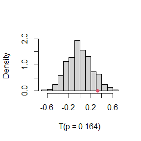

```r
## The histogram of replicates  is shown as follow
hist(reps,main="",freq=FALSE,xlab="T(p = 0.164)",
breaks="scott")
points(c,0,cex=1,col=2,pch =16)
```

From the result we can see, the p-value 0.164 we obtianed with cor function computing is not very different from the p-value 0.164 we obtianed with the cor.test function. And both the p-value is bigger than 0.05, so under the 0.05 significance level, we think the two sample are not correlation.

### Question

Design experiments for evaluating the performance of the NN, energy, and ball methods in various situations. (1)Unequal variances and equal expectations (2)Unequal variances and unequal expectations (3)Non-normal distributions: t distribution with 1 df (heavy-tailed distribution), bimodel distribution (mixture of two normal distributions) (4)Unbalanced samples (say, 1 case versus 10 controls) (5)Note: The parameters should be chosen such that the powers are distinguishable (say, range from 0.3 to 0.8)

### Answer

```r
### NN
library(RANN) # implementing a fast algorithm
library(boot)
library(energy)
library(Ball)
library(knitr)
```

```r
### power compare
m<-1e3; k<-3; p<-2;
R<-999;
### Tn is the kth nearest neighbor statistic
Tn<-function(z,ix,sizes,k)
  {
   n1<-sizes[1]
   n2<-sizes[2]
   n<-n1+n2
   if(is.vector(z))z<-data.frame(z)
   z<-z[ix,]
   NN<-nn2(data=z, k=k+1)
   block1<-NN$nn.idx[1:n1,-1]
   block2<-NN$nn.idx[(n1+1):n,-1]
   i1<-sum(block1<=n1)
   i2<-sum(block2>n1)
   (i1+i2)/(k*n)
  }

### we can obtain the p-value of NN test from the eqdist.nn
eqdist.nn<-function(z,sizes,k)
  {
   boot.obj<-boot(data=z,statistic=Tn,R=R,sim="permutation",sizes=sizes,k=k)
   ts<-c(boot.obj$t0,boot.obj$t)
   p.value<-mean(ts>=ts[1])
   list(statistic=ts[1],p.value=p.value)
 }

### we compute the NN, energy, and ball's power when the random varible are normal
power_compare<-function(n1,n2,mu1,mu2,sigma1,sigma2){
   p_values<-matrix(NA,m,3)
   N<-c(n1,n2)
   for(i in 1:m)
  {
    x<-matrix(rnorm(n1*p,mu1,sigma1),ncol=p)
    y<-matrix(rnorm(n2*p,mu2,sigma2),ncol=p)
    z<-rbind(x,y)
    p_values[i,1]<-eqdist.nn(z,N,k)$p.value
    p_values[i,2]<-eqdist.etest(z,sizes=N,R=R)$p.value
    p_values[i,3]<-bd.test(x=x,y=y,num.permutations=R,seed=i*12345)$p.value
  }
  alpha<-0.05
  pow<-colMeans(p_values<alpha)
  pow ##the power vector
}
#we compute the NN, energy, and ball's power when the random varible are normal and student.
power_compare1<-function(n1,n2){
   p_values<-matrix(NA,m,3)
   N<-c(n1,n2)
  for(i in 1:m)
  {
    x<-matrix(rt(n1*p,1),ncol=p);
    y<-cbind(rnorm(n2),rnorm(n2,mean=1))
    z<-rbind(x,y)
    p_values[i,1]<-eqdist.nn(z,N,k)$p.value
    p_values[i,2]<-eqdist.etest(z,sizes=N,R=R)$p.value
    p_values[i,3]<-bd.test(x=x,y=y,num.permutations=R,seed=i*12345)$p.value
  }
  alpha<-0.05
  pow<-colMeans(p_values<alpha)
  pow ##the power vector
}
```

```r
## we use vector pow1,2,3,4 denote the power of three test under four cases
## In the following four cases, n1 and n2 were uniformly used to record the sample size of two samples, mu1 and mu2 were used to record the mean values of two normal samples, and sigma1 and sigma2 were used to record the standard deviations of two normal samples.

# pow1<-pow2<-pow3<-pow4<-numeric(3)
# ###(1)Unequal variances and equal expectations
# set.seed(12345)
# n1<-n2<-50; mu1<-mu2<-0; sigma1<-0.1; sigma2<-0.17;
# pow1<-power_compare(n1,n2,mu1,mu2,sigma1,sigma2)
#
# ###(2)Unequal variances and unequal expectations
# n1<-n2<-50; mu1<-0.15; mu2<-0.1; sigma1<-0.11; sigma2<-0.12
# pow2<-power_compare(n1,n2,mu1,mu2,sigma1,sigma2)
#
# ###(3)Non-normal distributions: t distribution with 1 df (heavy-tailed distribution), bimodel distribution (mixture of two normal distributions)
# n1<-n2<-30 ;
# pow3<-power_compare1(n1,n2)
#
# ###(4)Unbalanced samples (say, 1 case versus 10 controls)
# n1<-10; n2<-100 ; mu1<-mu2<-0; sigma1<-1; sigma2<-3
# pow4<-power_compare(n1,n2,mu1,mu2,sigma1,sigma2)
#
# res<-rbind(pow1=round(pow1,4),pow2=round(pow2,4),pow3=round(pow3,4),pow4=round(pow4,4))
# colnames(res)<-paste0(c("NN","energy","Ball"))
# kable(res,digits = getOption("digits"),align = "lccrr")
```

#### eighth homework

### Question 9.3

Use the Metropolis-Hastings sampler to generate random variables from a standard Cauchy distribution. Discard the first 1000 of the chain, and compare the deciles of the generated observations with the deciles of the standard Cauchy distribution (see qcauchy or qt with df=1). Recall that a Cauchy($\theta$,$\eta$) distribution has density function
$$f(x)={\frac{1}{\theta\pi(1+[(x-\eta)/\theta]^2)}},-\infty<x<\infty,\theta>0.$$
The standard Cauchy has the Cauchy($\theta$=1, $\eta$= 0) density. (Note that the standard Cauchy density is equal to the Student t density with one degree of freedom.)

### Answer

we choose normal distribution as the proposal distribution.

```r
library(knitr)
set.seed(23466)
#####
y<-rnorm(1)
#####
m<-1e2
x<-numeric(m)   ### Markov chains
x[1]<-rnorm(1)
k<-0  #### The chain length
u<-runif(m)
 for (i in 2:m) {
            y<-rnorm(1,x[i-1],5)
                if(u[i] <= (dt(y,1)/dt(x[i-1],1)))
                    x[i] <- y
                else {
                    x[i] <- x[i-1]
                    k <-k+1
                } }
index<-11:100
    y1<-x[index]
Q_sample<-quantile(y1,0.1)
a<-ppoints(100)
Q_Cauchy<-qt(0.1,1)
Quantile<-data.frame(sample_quantile=Q_sample,Cauchy_quantile=Q_Cauchy)
  kable(Quantile)
```

|  | sample_quantile | Cauchy_quantile |
| --- | --- | --- |
| 10% | -0.7191548 | -3.077684 |

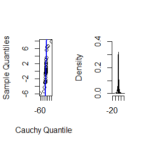

```r
a<-ppoints(100)
Q_Cauchy1<-qt(a,1)
Q_sample1<-quantile(y1,a)
par(mfrow=c(1,2))
    qqplot(Q_Cauchy1,Q_sample1, main="",
        xlab="Cauchy Quantiles", ylab="Sample Quantiles")
    abline(0,1,col='blue',lwd=2)
    hist(y1, breaks="scott", main="", xlab="",ylim=c(0,0.4),xlim=c(-20,20),freq=FALSE)
    lines(Q_Cauchy1,dt(Q_Cauchy1,1))
```

### Question 9.8

This example appears in [40]. Consider the bivariate density.
$$f(x,y)\varpropto\left(\begin{array}{1}
n\\x\end{array}\right)y^{x+a-1}(1-y)^{n-x+b-1},x=0,1,...,n,0\leq{y}\leq{1}.$$
It can be shown (see e.g.[23]) that for fixed a, b, n, the conditional distributions are Binomial(n,y) and Beta(x+a,n-x+b). Use the Gibbs sampler to generate a chain with target joint density f(x,y).

### Answer

$$(X|Y)\sim Binomial(n,y)$$
$$(Y|X)\sim Beta(x+a,n-x+b).$$

we consider the case for a=2,b=3,n=100.

```r
#initialize constants and parameters
set.seed(11093)
N<-5000 #length of chain
burn<-1000 #burn-in length
X<-matrix(0, N, 2) #the chain, a bivariate sample
a<-2
b<-3
n<-100
###### generate the chain #####
X[1,]<-c(1, 0.1) #initialize
for(i in 2:N) {
y<-X[i-1,2]
X[i,1]<-rbinom(1,n,y)
x<-X[i,1]
X[i,2]<-rbeta(1,x+a,n-x+b)
}
b<-burn+1
M<-X[b:N,]
# compare sample statistics to parameters
colMeans(M)
```

```
## [1] 37.7045000  0.3777616
```

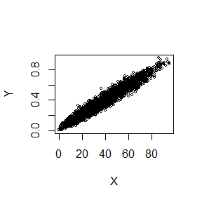

```r
plot(M, main="", cex=.5, xlab=bquote(X),ylab=bquote(Y), ylim=range(M[,2]))
```

bivariate chain generated by the Gibbs sampler plot in above.

### Question

For each of the above exercise, use the Gelman-Rubin method to monitor convergence of the chain, and run the chain until it converges approximately to the target distribution according to $\hat{R}<1.2$.

### Answer

1. Gelman-Rubin method to monitor convergence of the chain in 9.3

```r
Gelman.Rubin <- function(psi) {
                                # psi[i,j] is the statistic psi(X[i,1:j])
                               # for chain in i-th row of X
    psi<-as.matrix(psi)
    n<-ncol(psi)
    k<-nrow(psi)
    psi.means<-rowMeans(psi)    #row means
    B<-n*var(psi.means)         #between variance est.
    psi.w<-apply(psi,1,"var")   #within variances
    W<-mean(psi.w)              #within est.
    v.hat<-W*(n-1)/n+(B/n)      #upper variance est.
    r.hat<-v.hat/W              #G-R statistic
    return(r.hat)
}
```

```r
Cauchy.chain <- function(N,X1)
  {
 #with Normal(X[t], 5) proposal distribution
 #and starting value X1
    x<-rep(0,N)
    x[1]<-X1
    u<-runif(N)
 for (i in 2:1000) {
            y <- rnorm(1,x[i-1],5)
                if (u[i]<=(dt(y,1)/dt(x[i-1],1)))
                    x[i] <-y
                else {
                    x[i] <- x[i-1]
                    k<-k+1 } }
    return(x)
}
```

```r
k<-4 #number of chains to generate
n<-2000 #length of chains
bu<-500 #burn-in length
#choose overdispersed initial values
x0<-c(-2, -1, 0.1, 0.5)
#generate the chains
set.seed(123455)
X<-matrix(0,nrow=k, ncol=n)
for (i in 1:k)
X[i,]<-Cauchy.chain(n, x0[i])
#compute diagnostic statistics
psi<-t(apply(X, 1, cumsum))
for (i in 1:nrow(psi))
psi[i,]<-psi[i,]/(1:ncol(psi))
print(Gelman.Rubin(psi))
```

```
## [1] 1.107312
```

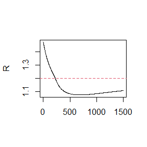

```r
#plot psi for the four chains
# par(mfrow=c(2,2))
# for (i in 1:k)
# plot(psi[i,(bu+1):n], type="l",
# xlab=i, ylab=bquote(psi))

rhat <- rep(0, n)
for(j in (bu+1):n)
rhat[j]<-Gelman.Rubin(psi[,1:j])
plot(rhat[(bu+1):n],type="l",xlab="",ylab="R")
abline(h=1.2, lty=2,col=2)
```

2. Gelman-Rubin method to monitor convergence of the chain in 9.8

```r
k<-4 #number of chains to generate
N<-1500 #length of chains
bu<-500 #burn-in length
#generate the chains
MC.chain<-function(N,x0){
X<-matrix(0, N, 2) #the chain, a bivariate sample
a<-2
b<-3
n<-100
###### generate the chain #####
X[1,]<-x0 #initialize
for(i in 2:N) {
y<-X[i-1,2]
X[i,1]<-rbinom(1,n,y)
x<-X[i,1]
X[i,2]<-rbeta(1,x+a,n-x+b)
}
return(X)
}
```

```r
set.seed(12345)
x0<-matrix(c(1,0.1,5,0.5),ncol=2)
X1<-MC.chain(N,x0[,1])
#X1
X2<-MC.chain(N,x0[,2])
Y<-cbind(X1,X2)
#compute diagnostic statistics
psi1<-apply(Y, 1, cumsum)
for (i in 1:nrow(psi1))
psi1[i,]<-psi1[i,]/(1:ncol(psi1))
print(Gelman.Rubin(psi1))
```

```
## [1] 1.011864
```

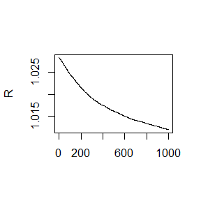

```r
#plot psi for the four chains
# par(mfrow=c(2,2))
# for (i in 1:4)
# plot(psi1[i,(bu+1):N], type="l",
# xlab=i)
# par(mfrow=c(1,1)) #restore default
#plot the sequence of R-hat statistics
rhat <- rep(0, N)
for(j in (bu+1):N)
 rhat[j]<-Gelman.Rubin(psi1[,1:j])
plot(rhat[(bu+1):N],type="l",xlab="",ylab="R")
abline(h=1.2, lty=2,col=2)
abline(h=1.1, lty=2,col=3)
```

#### nineth homework

### Question 11.3

1. Write a function to compute the $k^{th}$ term in
   $$\sum_{k=0}^{\infty}\frac{(-1)^k{\|a\|}^{2k+2}\Gamma(\frac{d+1}{2})\Gamma(k+\frac{3}{2})}{k!2^k(2k+1)(2k+2)\Gamma(k+\frac{d}{2}+1)}$$
   , where $d\geq1$ is an integer,a is a vector in $R^d$, and $\|\cdot\|$ denotes the Euclidean norm. Perform the arithmetic so that the coefficients can be computed for (almost) arbitrarily large k and d. (This sum converges for all $a\in{R^d}$).
2. Modify the function so that it computes and returns the sum. (c)Evaluate the sum when $a=(1,2)^T$.

### Answer

The function as follow

```r
##(a)
### the kth term,k!=gamma(k+1)
f<-function(k,a,d)
  {(-1)^k*exp(((2*k+2)*log(norm(a,type="F"))+lgamma((d+1)/2)+lgamma(k+3/2)-lgamma(k+1)-k*log(2)-log(2*k+1)-log(2*k+2)-lgamma(k+d/2+1)) )
}
k<-8
d<-3
a<-as.matrix(c(1,2,3))
f(k,a,d)
```

```
## [1] 0.6885679
```

```r
###(b)
# K<-0:1e5
# sum(f(k,a,d))
summ<-function(a,d)
{
  k=0
  x<-y<-f(k,a,d)
  while(x>1e-5){
   k=k+1
   x<-f(k,a,d)
   y<-y+x
  }
  y
}
```

The sum as follow

```r
### (c)
a<-matrix(c(1,2))
d<-2
summ(a,d)
```

```
## [1] 1.349903
```

### Quetion 11.5

Write a function to solve the equation
$$\frac{2\Gamma(\frac{k}{2})}{\sqrt{\pi(k-1)}\Gamma(\frac{k-1}{2})}\int_0^{c_{k-1}}(1+\frac{u^2}{k-1})^{-k/2}du$$
$$=\frac{2\Gamma(\frac{k+1}{2})}{\sqrt{\pi{k}}\Gamma(\frac{k}{2})}\int_0^{c_{k}}(1+\frac{u^2}{k})^{-(k+1)/2}du$$
, for a, where
$$c_k=\sqrt{\frac{a^2k}{k+1-a^2}}$$
. Compare the solutions with the points A(k) in Exercise 11.4.

### Answer

```r
k<-c(4:25,100,500,1000)
s<-function(k,a){
  return(pt(sqrt(a^2*k/(k+1-a^2)),df=k,lower.tail = F))
}
delta.s <- function(k,a){
  s(k,a)-s(k-1,a)
}
n<-length(k)
A<-numeric(n)
for(i in 1:n){
  A[i]<-uniroot(delta.s,interval=c(1,2),k=k[i])$root
}
result<-cbind(k,A)
knitr::kable(result)
```

| k | A |
| --- | --- |
| 4 | 1.492103 |
| 5 | 1.533556 |
| 6 | 1.562744 |
| 7 | 1.584430 |
| 8 | 1.601185 |
| 9 | 1.614521 |
| 10 | 1.625390 |
| 11 | 1.634419 |
| 12 | 1.642038 |
| 13 | 1.648554 |
| 14 | 1.654190 |
| 15 | 1.659114 |
| 16 | 1.663452 |
| 17 | 1.667304 |
| 18 | 1.670745 |
| 19 | 1.673840 |
| 20 | 1.676637 |
| 21 | 1.679178 |
| 22 | 1.681496 |
| 23 | 1.683620 |
| 24 | 1.685572 |
| 25 | 1.687373 |
| 100 | 1.720608 |
| 500 | 1.729756 |
| 1000 | 1.730908 |

```r
#11.5
f1<-function(u)(1+u^2/(k-1))^(-k/2)
f2<-function(u)(1+u^2/(k))^(-(k+1)/2)
m<-function(k)exp(log(2)+lgamma(k/2)-0.5*(log(pi)+log(k-1))-lgamma((k-1)/2))
fu<-function(k){
  f<-function(a){
  m(k)*integrate(f1,lower=0,upper=sqrt(a^2*(k-1)/(k-a^2)),rel.tol=.Machine$double.eps^0.25)$value-m(k+1)*integrate(f2,lower=0,upper=sqrt(a^2*k/(k+1-a^2)),rel.tol=.Machine$double.eps^0.25)$value
}
uniroot(f,c(-1e-7,1.99))$root
}
res<-numeric(25)
for(k in 4:25)
  res[k-3]<-fu(k)
```

```r
f<-function(a){
  m(k)*integrate(f1,lower=0,upper=sqrt(a^2*(k-1)/(k-a^2)),rel.tol=.Machine$double.eps^0.25)$value-m(k+1)*integrate(f2,lower=0,upper=sqrt(a^2*k/(k+1-a^2)),rel.tol=.Machine$double.eps^0.25)$value
}
k<-100
res[23]<-uniroot(f,c(-1e-7,1.99))$root
k<-500
res[24]<-uniroot(f,c(-1e-7,1.99))$root
k<-1000
res[25]<-uniroot(f,c(-1e-7,1.99))$root
res
```

```
##  [1] 1.492102 1.533558 1.562723 1.584430 1.601184 1.614520 1.625388 1.634416
##  [9] 1.642035 1.648550 1.654186 1.659110 1.663448 1.667299 1.670740 1.673835
## [17] 1.676632 1.679172 1.681490 1.683614 1.685566 1.687367 1.720607 1.729754
## [25] 1.730906
```

### Question

Suppose $T_1,...,T_n$ are i.i.d. samples drawn from the exponential distribution with expectation $\lambda$. Those values greater than $\tau$ are not observed due to right censorship, so that the observed values are $Y_i=T_iI(T_i\leq{\tau})+\tau{I(T_i>\tau)},i=1,...,n$. Suppose $\tau$= 1 and the observed $T_i$ values are as follows: 0.54, 0.48, 0.33, 0.43, 1.00, 1.00, 0.91, 1.00, 0.21, 0.85 Use the E-M algorithm to estimate $\lambda$, compare your result with the observed data MLE (note: $Y_i$ follows a mixture distribution).

### Answer

- EM observed data: $T_1,T_2,...,T_r,1,...,1,T_i$ is less than 1,the sample size is denote n, complete data: $T_1,...,T_n$
  - Observed data likelihood
    $$L(\lambda|T_1,T_2,...,T_r,1,...,1)=\prod_{i=1}^r(\frac{1}{\lambda}e^{-\frac{T_i}{\lambda}})(e^{-\frac{1}{\lambda}})^{n-r}$$
    $$\lambda_{MLE}=\frac{\sum_{i=1}^r+n-r}{r}=\frac{6.75}{7}=0.964285$$
  - Complete data likelihood
    $$L(\lambda|T_1,T_2,...,T_n)=\prod_{i=1}^n(\frac{1}{\lambda}e^{-\frac{T_i}{\lambda}})$$
    $$l(\lambda|T_1,T_2,...,T_n)=-nlog{\lambda}-\frac{\sum_{i=1}^nT_i}{\lambda}$$
  - E-step: $E_{\hat \lambda_0}[l(\lambda|T_1,T_2,...,T_n)|T_1,T_2,...,T_r,1,...,1]=-nlog\lambda-\frac{\sum_{i=1}^rT_i+(n-r)+(n-r){\hat\lambda_0}}{\lambda}$
  - M-step: $\hat \lambda_1=\frac{\sum_{i=1}^rT_i+(n-r)+(n-r)\hat\lambda_0}{n}$.
  - The converged $p$ estimate (monotone, bounded) is the solution of the equation
    $$\lambda=\frac{\sum_{i=1}^rT_i+(n-r)+(n-r)\lambda}{n}\Rightarrow \tilde \lambda=\frac{\sum_{i=1}^rT_i+n-r}{r}==\frac{6.75}{7}=0.964285$$
  - The EM estimate is exactly the observed data MLE!

#### tenth homework

### Question

1.Why are the following two invocations of lapply() equivalent?

```r
trims<-c(0, 0.1, 0.2, 0.5)
x<-rcauchy(100)
lapply(trims,function(trim)mean(x,trim=trim))
```

```
## [[1]]
## [1] -1.396247
##
## [[2]]
## [1] 0.1779981
##
## [[3]]
## [1] 0.08534336
##
## [[4]]
## [1] -0.06115359
```

```r
lapply(trims, mean, x=x)
```

```
## [[1]]
## [1] -1.396247
##
## [[2]]
## [1] 0.1779981
##
## [[3]]
## [1] 0.08534336
##
## [[4]]
## [1] -0.06115359
```

### Answer

Because we write the function(trim) mean(x, trim = trim), which is equal to we we use mean(x,trim=trims) directly, In the later, we vary a argument, trims is not the first argument for mean() for we denote x=x.

### Question

5. For each model in the previous two exercises, extract $R^2$ using the function below.

### Answer

```r
##(5)
rsq<-function(mod){summary(mod)$r.squared}
###3. Use both for loops and lapply() to fit linear models to the
#mtcars using the formulas stored in this list:
data1<-mtcars
formulas<-list(
 mpg~disp,
 mpg~I(1/disp),
 mpg~disp+wt,
 mpg~I(1/disp)+wt
)
l1<-lapply(formulas,lm,data=data1)
print("In Exercise 3, the R^2 for each model is below")
```

```
## [1] "In Exercise 3, the R^2 for each model is below"
```

```r
lapply(l1,rsq)
```

```
## [[1]]
## [1] 0.7183433
##
## [[2]]
## [1] 0.8596865
##
## [[3]]
## [1] 0.7809306
##
## [[4]]
## [1] 0.8838038
```

```r
### 4. Fit the model mpg~disp to each of the bootstrap replicatesof mtcars in #the list below by using a for loop and lapply(). Can you do it without an #anonymous function?
bootstraps<-lapply(1:10,function(i){
    rows<-sample(1:nrow(mtcars),rep=TRUE)
    mtcars[rows,]
  })
l2<-lapply(bootstraps,lm,formula=mpg~disp)
print("In  Exercise 4, the R^2 for each model is below")
```

```
## [1] "In  Exercise 4, the R^2 for each model is below"
```

```r
lapply(l2, rsq)
```

```
## [[1]]
## [1] 0.629107
##
## [[2]]
## [1] 0.775777
##
## [[3]]
## [1] 0.686455
##
## [[4]]
## [1] 0.7659514
##
## [[5]]
## [1] 0.7307956
##
## [[6]]
## [1] 0.8118327
##
## [[7]]
## [1] 0.7707617
##
## [[8]]
## [1] 0.7057617
##
## [[9]]
## [1] 0.7930436
##
## [[10]]
## [1] 0.7004735
```

For each model in the previous two exercises, the $R^2$ are above.

### Question

1. Use vapply() to:
1. Compute the standard deviation of every column in a numeric data frame.
2. Compute the standard deviation of every numeric column in a mixed data frame. (Hint: you’ll need to use vapply() twice.)

### Answer

```r
#(a)the standard deviation of every column in a numeric data frame.
vapply(data1,sd,FUN.VALUE=c(sd=0))
```

```
##         mpg         cyl        disp          hp        drat          wt
##   6.0269481   1.7859216 123.9386938  68.5628685   0.5346787   0.9784574
##        qsec          vs          am        gear        carb
##   1.7869432   0.5040161   0.4989909   0.7378041   1.6152000
```

```r
#(b)the standard deviation of every numeric column in a mixed data frame.
data2<-esoph
summary1<-function(x){
vapply(x,as.numeric,FUN.VALUE=c(value1=0))
}
round(vapply(data2,function(x)(sd(summary1(x))),FUN.VALUE=c(sd=0)),3)
```

```
##     agegp     alcgp     tobgp    ncases ncontrols
##     1.650     1.124     1.121     2.753    12.135
```

In above, we can see, if the data is numeric, we use vapply function only once, if the data is mix,for example in (b), data esoph is a mixture data, we should use vapply function twice.

### Question

7. Implement mcsapply(),a multicore version of sapply().Can you implement mcvapply(), a parallel version of vapply()? Why or why not?

### Answer

The mcsapply() and mcvapply() as follow.

```r
library(parallel)
n<-10
cl<-makeCluster(mc <-getOption("cl.cores", 2))
parLapply(cl,1:n,sqrt)
```

```
## [[1]]
## [1] 1
##
## [[2]]
## [1] 1.414214
##
## [[3]]
## [1] 1.732051
##
## [[4]]
## [1] 2
##
## [[5]]
## [1] 2.236068
##
## [[6]]
## [1] 2.44949
##
## [[7]]
## [1] 2.645751
##
## [[8]]
## [1] 2.828427
##
## [[9]]
## [1] 3
##
## [[10]]
## [1] 3.162278
```

```r
#### we write the mcsapply based parLapply
mcsapply<-function(cl=NULL,X, fun, ...) {

     res<-parLapply(cl,X, fun, ...)
     simplify2array(res)
}
mcvapply<-function(cl,X, fun, fun.value,...){

     fun1<-function(x)x
     vapply(parLapply(cl,X,fun),fun1,FUN.VALUE=fun.value,...)
}
mcsapply(cl,1:n,sqrt)
```

```
##  [1] 1.000000 1.414214 1.732051 2.000000 2.236068 2.449490 2.645751 2.828427
##  [9] 3.000000 3.162278
```

#### eleventh homework

### Question1

Write an Rcpp function for Exercise 9.8 (page 278, Statistical Computing with R)

### Answer1

I write a Rcpp function for the Exercise 9.8 as follow.

```r
#include <Rcpp.h>
using namespace Rcpp;
//[[Rcpp::export]]
NumericMatrix gibbsC(int a,int b,int n) {
  int N = 10000;
  NumericMatrix X(N,2);
  double x=0,y=0;
  X(0,0)=0;
  X(0,1)=0.3;
  for(int i=1; i<N; ++i) {
    y=X(i-1,1);
    X(i,0)=rbinom(1,n,y)[0];
    x=X(i,0);
    X(i,1)=rbeta(1,x+a,n-x+b)[0];
  }
  return (X);
}
```

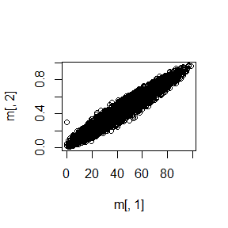

```r
library(Rcpp)
library(StatComp21027)
 m<-gibbsC(2,3,100)
 plot(m[,1],m[,2])
```

### Question2

Compare the corresponding generated random numbers with pure R language using the function “qplot”?.

### Answer2

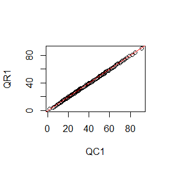

```r
    set.seed(12)
    x_C<-gibbsC(2,3,100)
    y_R<-gibbsR(2,3,100)
## we will draw the qqplot
c<-ppoints(100)
QC1<-quantile(x_C[,1],c)
QR1<-quantile(y_R[,1],c)
QC2<-quantile(x_C[,2],c)
QR2<-quantile(y_R[,2],c)
 qqplot(QC1,QR1,main="",xlab="QC1", ylab="QR1")
 abline(0,1,col = "red")
```

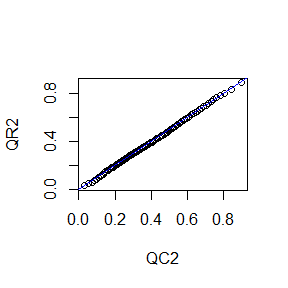

```r
 qqplot(QC2,QR2,main="",xlab="QC2", ylab="QR2")
 abline(0,1,col = "blue")
```

As can be seen from the QQ chart, the quantiles of the two samples are roughly the same, so their distribution is also roughly the same.

### Question3

Campare the computation time of the two functions with the function “microbenchmark” ?.

### Answer3

```r
library(microbenchmark)
ts <- microbenchmark(gibbR=gibbsR(2,3,100),
gibbC=gibbsC(2,3,100))
summary(ts)[,c(1,3,5,6)]
```

```
##    expr       lq   median       uq
## 1 gibbR 45.13160 53.78035 57.79765
## 2 gibbC  9.29915  9.89230 10.93245
```

Campare the computation time of the two functions gibbsC and gibbsR we can see, the time of C++ to loop is less than R obviously.

### Question4

Comments your results.

### Answer4

Each programming language has its own specific advantages, and we should make full use of the advantages of each language and use multiple programming languages together to create more efficient and convenient code.